# Figure script — GTEx vs TCGA age-trend comparison (Part 2)

Pan-cancer aging pipeline

August 12, 2026

## Overview

This script loads the saved Part 2 analysis outputs (scripts 02 and 03) and builds the GTEx vs TCGA age-trend comparison panels. The analysis scripts own all modeling; this script only formats saved tables into figure panels.

Panels produced:

- Pan-tissue pathway agreement (within-cohort meta-analysis, GTEx vs TCGA).
- Pan-tissue cell-type agreement (within-cohort meta-analysis, GTEx vs TCGA).
- Combined per-tissue pathway and cell-type agreement across the four emphasis tissues, with a nested x-axis (modality over category) and a shared per-tissue y-axis.

A shared legend follows the per-tissue panel. A full-sized pathway supplement (pan-tissue and per-tissue, all categories) is produced at the end.

Some panels may not appear in the published manuscript. Panels are assembled and typeset in Adobe Illustrator to produce the final figure.

All panels encode dot color by age-trend direction and significance (FDR < 0.05), and dot size by signed significance (`-log10(FDR)`, capped at 5). Size is on a fixed scale (`limits = c(0, 5)`) across every panel, so dot sizes are directly comparable and a single size legend applies throughout. Pathway name cleaning and category assignment follow the same conventions as the cross-cancer figure. Cell-type fibroblast proportions are estimated via EPIC’s CAF-like reference and labeled “Fibroblasts”; the caption notes the reference origin.

## Libraries

```r
suppressPackageStartupMessages({
  library(dplyr)
  library(tidyr)
  library(stringr)
  library(tibble)
  library(ggplot2)
  library(here)
  library(grid)
  library(ggh4x)
})
```

## Paths and shared plot helpers

```r
rnaseq_root   <- here::here(params$rnaseq_root)
celltype_root <- here::here(params$celltype_root)
figures_root  <- here::here(params$figures_root)
tables_root   <- here::here(params$tables_root)

dir.create(figures_root, recursive = TRUE, showWarnings = FALSE)
dir.create(tables_root,  recursive = TRUE, showWarnings = FALSE)

agreement_fill_values <- c(
  "Up_Sig"   = "#d62728",
  "Up_NS"    = "#f4a3a3",
  "Down_Sig" = "#1f77b4",
  "Down_NS"  = "#9ecae1",
  "Neutral"  = "grey85"
)

agreement_legend_labels <- c(
  "Increase with Age (FDR < 0.05)",
  "Increase with Age (FDR \u2265 0.05)",
  "Decrease with Age (FDR < 0.05)",
  "Decrease with Age (FDR \u2265 0.05)"
)

agreement_size_range <- c(1.2, 4.5)   # smaller max bubble to fit the densest panel (A)
agreement_size_limits <- c(0, 5)   # fixed across every panel so dot sizes are comparable
agreement_shape <- 21
agreement_alpha <- 0.9
```

## Shared dictionaries

Pathway cleaning and category assignment match the cross-cancer figure. Input pathway names arrive as raw MSigDB labels (`HALLMARK_*`); they are stripped, spaced, title-cased, and recoded for the acronym cases, then mapped to the same category scheme used elsewhere in the manuscript.

```r
clean_pathway_label <- function(x) {
  x <- stringr::str_remove(x, "^HALLMARK_")
  x <- stringr::str_replace_all(x, "_", " ")
  x <- stringr::str_to_title(x)

  dplyr::recode(
    x,
    "Reactive Oxygen Species Pathway" = "ROS Pathway",
    "Il2 Stat5 Signaling" = "IL2/STAT5 Signaling",
    "Il6 Jak Stat3 Signaling" = "IL6/JAK/STAT3",
    "Tnfa Signaling Via Nfkb" = "TNFa → NFkB",
    "Pi3k Akt Mtor Signaling" = "PI3K/AKT/MTOR Signaling",
    "Epithelial Mesenchymal Transition" = "EMT",
    "Wnt Beta Catenin Signaling" = "WNT/β-Catenin",
    "Interferon Alpha Response" = "IFNa Response",
    "Interferon Gamma Response" = "IFNy Response",
    "Xenobiotic Metabolism" = "Xenobiotic Metab.",
    "Unfolded Protein Response" = "UPR",
    "Inflammatory Response" = "Inflammatory Resp.",
    "Fatty Acid Metabolism" = "Fatty Acid Metab.",
    .default = x
  )
}

# Exact-match category map for all 50 Hallmark pathways.
# Keys must match the output of clean_pathway_label().
hallmark_category_map <- c(
  # Proliferation
  "E2f Targets" = "Proliferation",
  "G2m Checkpoint" = "Proliferation",
  "Mitotic Spindle" = "Proliferation",
  "Myc Targets V1" = "Proliferation",
  "Myc Targets V2" = "Proliferation",

  # Immune
  "Allograft Rejection" = "Immune",
  "Complement" = "Immune",
  "Coagulation" = "Immune",
  "IL2/STAT5 Signaling" = "Immune",
  "IL6/JAK/STAT3" = "Immune",
  "Inflammatory Resp." = "Immune",
  "IFNa Response" = "Immune",
  "IFNy Response" = "Immune",
  "TNFa → NFkB" = "Immune",

  # Metabolic
  "Adipogenesis" = "Metabolic",
  "Bile Acid Metabolism" = "Metabolic",
  "Cholesterol Homeostasis" = "Metabolic",
  "Fatty Acid Metab." = "Metabolic",
  "Glycolysis" = "Metabolic",
  "Heme Metabolism" = "Metabolic",
  "Oxidative Phosphorylation" = "Metabolic",
  "Peroxisome" = "Metabolic",
  "Xenobiotic Metab." = "Metabolic",

  # DNA damage / stress
  "Apoptosis" = "DNA Damage",
  "Dna Repair" = "DNA Damage",
  "Hypoxia" = "DNA Damage",
  "P53 Pathway" = "DNA Damage",
  "ROS Pathway" = "DNA Damage",
  "UPR" = "DNA Damage",
  "Uv Response Dn" = "DNA Damage",
  "Uv Response Up" = "DNA Damage",

  # Signaling
  "Hedgehog Signaling" = "Signaling",
  "Kras Signaling Dn" = "Signaling",
  "Kras Signaling Up" = "Signaling",
  "Mtorc1 Signaling" = "Signaling",
  "Notch Signaling" = "Signaling",
  "PI3K/AKT/MTOR Signaling" = "Signaling",
  "Tgf Beta Signaling" = "Signaling",
  "WNT/β-Catenin" = "Signaling",

  # Hormone
  "Androgen Response" = "Hormone",
  "Estrogen Response Early" = "Hormone",
  "Estrogen Response Late" = "Hormone",

  # Cell state
  "Angiogenesis" = "Cell State",
  "Apical Junction" = "Cell State",
  "Apical Surface" = "Cell State",
  "EMT" = "Cell State",
  "Myogenesis" = "Cell State",
  "Pancreas Beta Cells" = "Cell State",
  "Protein Secretion" = "Cell State",
  "Spermatogenesis" = "Cell State"
)

assign_pathway_category <- function(pathway) {
  out <- unname(hallmark_category_map[pathway])
  out[is.na(out)] <- "Other"
  out
}

pathway_category_levels <- c(
  "Proliferation", "Immune", "Metabolic", "DNA Damage",
  "Signaling", "Hormone", "Cell State", "Other"
)

# The per-tissue panel focuses the pathway block on the three primary biological
# axes to stay readable. Change this vector to show more categories.
focus_categories_panelC <- c("Proliferation", "Immune", "Metabolic")

# Emphasis-cancer and tissue ordering (matches cross-cancer figure conventions).
matched_cohort_levels <- c("GTEx", "BRCA", "LUSC", "LUAD", "GBM", "LGG", "COAD")
matched_tissue_levels <- c("BREAST", "LUNG", "BRAIN", "COLON")

cell_label_map <- c(
  "otherCells"  = "Other Cells",
  "Bcells"      = "B Cells",
  "NKcells"     = "NK Cells",
  "CD4_Tcells"  = "CD4 T Cells",
  "CD8_Tcells"  = "CD8 T Cells",
  "Endothelial" = "Endothelial Cells",
  "Macrophages" = "Macrophages",
  "CAFs"        = "Fibroblasts"
)

cell_category_of <- function(cell_group) {
  dplyr::case_when(
    cell_group %in% c("Macrophages", "NKcells") ~ "Innate",
    cell_group %in% c("Bcells", "CD4_Tcells", "CD8_Tcells") ~ "Adaptive",
    cell_group %in% c("CAFs", "Endothelial") ~ "Stromal",
    TRUE ~ "Other"
  )
}

# Shared per-tissue row positions (used by the per-tissue panel); gaps separate tissue/tumor
# blocks. Top to bottom: Breast, Lung, Brain, Colon.
gtex_to_display <- c(
  "GTEx-BREAST" = "Breast",
  "GTEx-LUNG"   = "Lung",
  "GTEx-BRAIN"  = "Brain",
  "GTEx-COLON"  = "Colon"
)

display_top_to_bottom <- c(
  "Breast", "BRCA",
  "Lung",   "LUSC", "LUAD",
  "Brain",  "GBM",  "LGG",
  "Colon",  "COAD"
)

row_pos_tbl <- tibble::tibble(
  RowLab = display_top_to_bottom,
  RowPos = c(
    10.0, 9.0,      # Breast block
     7.6, 6.6, 5.6, # Lung block
     4.2, 3.2, 2.2, # Brain block
     0.8, -0.2      # Colon block
  )
)
```

## Load saved analysis outputs

```r
pathway_meta_long <- readRDS(file.path(rnaseq_root, "pathways", "pathway_meta_long.rds")) %>%
  dplyr::mutate(Pathway = clean_pathway_label(Pathway))

pathway_matched_long <- readRDS(file.path(rnaseq_root, "pathways", "pathway_matched_long.rds")) %>%
  dplyr::mutate(Pathway = clean_pathway_label(Pathway))

celltype_meta_all <- readRDS(file.path(celltype_root, "meta", "celltype_meta_all.rds"))
celltype_matched_long <- readRDS(file.path(celltype_root, "meta", "celltype_matched_long.rds"))
```

## Pan-tissue pathway agreement

Global within-cohort pathway meta-analysis (GTEx vs TCGA), restricted to pathways significant in at least one cohort. Dot size is signed significance (`-log10(FDR)`), harmonized with the other panels.

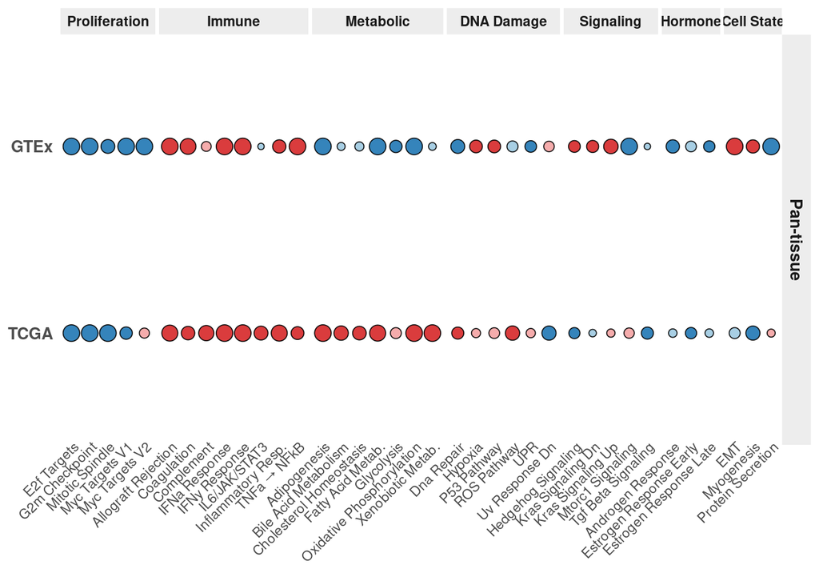

```r
plot_pathway_meta <- pathway_meta_long %>%
  dplyr::transmute(
    Pathway,
    Cohort = factor(Cohort, levels = c("TCGA", "GTEx")),   # GTEx on top (first level = bottom)
    fdr,
    DirLabel = direction,
    Size = pmin(-log10(pmax(fdr, 1e-300)), 5)   # signed significance, harmonized across the figure
  )

sig_paths <- plot_pathway_meta %>%
  dplyr::group_by(Pathway) %>%
  dplyr::summarise(any_sig = any(fdr < 0.05, na.rm = TRUE), .groups = "drop") %>%
  dplyr::filter(any_sig) %>%
  dplyr::pull(Pathway)

plot_pathway_meta <- plot_pathway_meta %>%
  dplyr::filter(Pathway %in% sig_paths) %>%
  dplyr::mutate(
    Category = assign_pathway_category(Pathway),
    Category = factor(Category, levels = pathway_category_levels),
    Pathway_wrapped = stringr::str_wrap(Pathway, width = 30)
  )

# Order pathways alphabetically within category, matching the per-tissue panel's convention.
alpha_order <- plot_pathway_meta %>%
  dplyr::distinct(Category, Pathway, Pathway_wrapped) %>%
  dplyr::arrange(Category, Pathway) %>%
  dplyr::pull(Pathway_wrapped) %>%
  unique()

plot_pathway_meta <- plot_pathway_meta %>%
  dplyr::mutate(
    Section = "Pan-tissue",
    Pathway_wrapped = factor(Pathway_wrapped, levels = alpha_order),
    Sig = ifelse(fdr < 0.05, "Sig", "NS"),
    Color = dplyr::case_when(
      DirLabel == "Up"   & Sig == "Sig" ~ unname(agreement_fill_values["Up_Sig"]),
      DirLabel == "Up"   & Sig == "NS"  ~ unname(agreement_fill_values["Up_NS"]),
      DirLabel == "Down" & Sig == "Sig" ~ unname(agreement_fill_values["Down_Sig"]),
      DirLabel == "Down" & Sig == "NS"  ~ unname(agreement_fill_values["Down_NS"]),
      TRUE ~ unname(agreement_fill_values["Neutral"])
    )
  )

fig2_font <- list(
  base = 10,
  strip_y = 8.5,
  strip_section = 10,
  axis_x = 10,
  axis_y = 10
)

p_pathway_meta <- ggplot(plot_pathway_meta, ggplot2::aes(x = Pathway_wrapped, y = Cohort)) +
  ggplot2::geom_point(
    ggplot2::aes(size = Size, fill = Color),
    shape = agreement_shape, color = "black", alpha = agreement_alpha
  ) +
  ggplot2::facet_grid(Section ~ Category, scales = "free_x", space = "free_x") +
  ggplot2::scale_fill_identity() +
  ggplot2::scale_size(range = agreement_size_range, limits = agreement_size_limits, guide = "none") +
  ggplot2::theme_minimal(base_size = fig2_font$base) +
  ggplot2::theme(
    legend.position = "none",
    axis.title.y = ggplot2::element_blank(),
    axis.title.x = ggplot2::element_blank(),
    panel.spacing.x = grid::unit(0.15, "lines"),
    strip.text.x = ggplot2::element_text(
      size = fig2_font$strip_y,
      face = "bold"
    ),
    strip.text.y = ggplot2::element_text(
      size = fig2_font$strip_section,
      face = "bold",
      angle = -90
    ),
    strip.background = ggplot2::element_rect(fill = "grey93", color = NA),
    axis.text.x = ggplot2::element_text(
      size = 8.5,
      angle = 45,
      hjust = 1,
      vjust = 1.1
    ),
    axis.text.y = ggplot2::element_text(
      size = fig2_font$axis_x,
      face = "bold"
    ),
    panel.grid.major = ggplot2::element_blank(),
    panel.grid.minor = ggplot2::element_blank()
  )

p_pathway_meta
```

```r
ggsave(file.path(figures_root, "fig_pancohort_pathway.pdf"), p_pathway_meta,
       width = 7.5, height = 2.5, units = "in")
message("Saved: fig_pancohort_pathway.pdf")
```

## Pan-tissue cell-type agreement

Global within-cohort cell-type meta-analysis (GTEx vs TCGA). Mirrors the pan-tissue pathway panel, with cell categories as the column facets.

This panel applies Benjamini-Hochberg FDR (p.adjust) to the meta p-values in celltype_meta_all, computed within each cohort. The per-tissue cell-type panel uses sccomp’s c_FDR directly, since each row there is a single sccomp fit. Both quantities are thresholded at 0.05 and mapped onto the same -log10(FDR) size scale, but the underlying computations differ by necessity: a meta-analysis of effect sizes does not produce a c_FDR, and a per-fit sccomp result does not produce a frequentist p-value to BH-adjust.

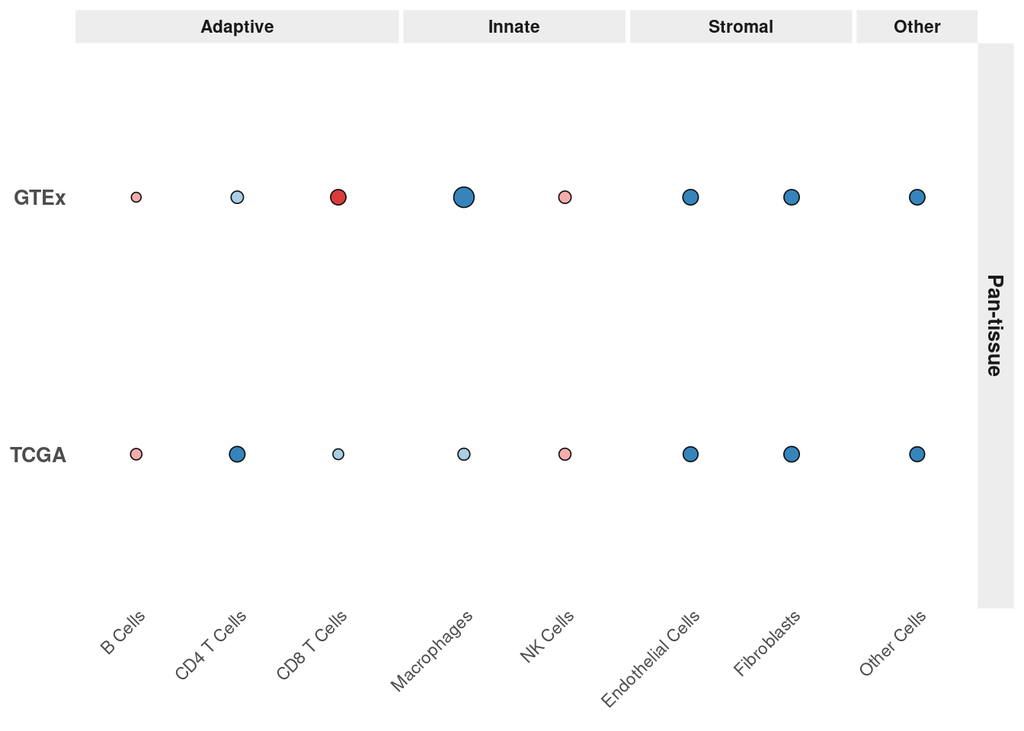

```r
plot_celltype_meta <- celltype_meta_all %>%
  dplyr::group_by(Cohort) %>%
  dplyr::mutate(fdr = stats::p.adjust(pval, method = "fdr")) %>%
  dplyr::ungroup() %>%
  dplyr::mutate(
    Cohort  = factor(Cohort, levels = c("TCGA", "GTEx")),   # GTEx on top (first level = bottom)
    Section = "Pan-tissue",
    Sig = ifelse(!is.na(fdr) & fdr < 0.05, "Sig", "NS"),
    Dir = dplyr::case_when(
      is.na(est) ~ "NA", est > 0 ~ "Pos", est < 0 ~ "Neg", TRUE ~ "Zero"
    ),
    Color = dplyr::case_when(
      Dir == "Pos" & Sig == "Sig" ~ unname(agreement_fill_values["Up_Sig"]),
      Dir == "Pos" & Sig == "NS"  ~ unname(agreement_fill_values["Up_NS"]),
      Dir == "Neg" & Sig == "Sig" ~ unname(agreement_fill_values["Down_Sig"]),
      Dir == "Neg" & Sig == "NS"  ~ unname(agreement_fill_values["Down_NS"]),
      TRUE ~ unname(agreement_fill_values["Neutral"])
    ),
    Score = sign(dplyr::coalesce(est, 0)) * -log10(pmax(fdr, 1e-300)),
    Size  = pmin(abs(Score), 5),
    Category = factor(cell_category_of(Cell_Group),
                      levels = c("Adaptive", "Innate", "Stromal", "Other")),
    Cell_Group_pretty = dplyr::recode(Cell_Group, !!!cell_label_map),
    Cell_wrapped = stringr::str_wrap(Cell_Group_pretty, width = 18)
  )

# order cell types within each category (alphabetical), consistent with the per-tissue panel
cell_order <- plot_celltype_meta %>%
  dplyr::distinct(Category, Cell_wrapped) %>%
  dplyr::arrange(Category, Cell_wrapped) %>%
  dplyr::pull(Cell_wrapped) %>%
  unique()

plot_celltype_meta <- plot_celltype_meta %>%
  dplyr::mutate(Cell_wrapped = factor(Cell_wrapped, levels = cell_order))

fig2_font <- list(
  base = 10,
  strip_y = 8.5,
  strip_section = 10,
  axis_x = 10,
  axis_y = 10
)

p_celltype_meta <- ggplot(plot_celltype_meta, ggplot2::aes(x = Cell_wrapped, y = Cohort)) +
  ggplot2::geom_point(
    ggplot2::aes(size = Size, fill = Color),
    shape = agreement_shape, color = "black", alpha = agreement_alpha
  ) +
  ggplot2::facet_grid(Section ~ Category, scales = "free_x", space = "free_x") +
  ggplot2::scale_fill_identity() +
  ggplot2::scale_size(range = agreement_size_range, limits = agreement_size_limits, guide = "none") +
  ggplot2::theme_minimal(base_size = fig2_font$base) +
  ggplot2::theme(
    legend.position = "none",
    axis.title.y = ggplot2::element_blank(),
    axis.title.x = ggplot2::element_blank(),
    panel.spacing.x = grid::unit(0.15, "lines"),
    strip.text.x = ggplot2::element_text(
      size = fig2_font$strip_y,
      face = "bold"
    ),
    strip.text.y = ggplot2::element_text(
      size = fig2_font$strip_section,
      face = "bold",
      angle = -90
    ),
    strip.background = ggplot2::element_rect(fill = "grey93", color = NA),
    axis.text.x = ggplot2::element_text(
      size = 8.5,
      angle = 45,
      hjust = 1,
      vjust = 1.1
    ),
    axis.text.y = ggplot2::element_text(
      size = fig2_font$axis_x,
      face = "bold"
    ),
    panel.grid.major = ggplot2::element_blank(),
    panel.grid.minor = ggplot2::element_blank()
  )

p_celltype_meta
```

```r
ggsave(file.path(figures_root, "fig_pancohort_celltype.pdf"), p_celltype_meta,
       width = 4, height = 2, units = "in")
message("Saved: fig_pancohort_celltype.pdf")
```

## Combined per-tissue pathways and cell types

Per-tissue agreement for both modalities in one panel: shared per-tissue y-axis (normal tissue above its tumors within each block), nested x-axis with modality (“Pathways”, “Cell Types”) over category. Dot size is signed significance for both modalities, so they share one scale.

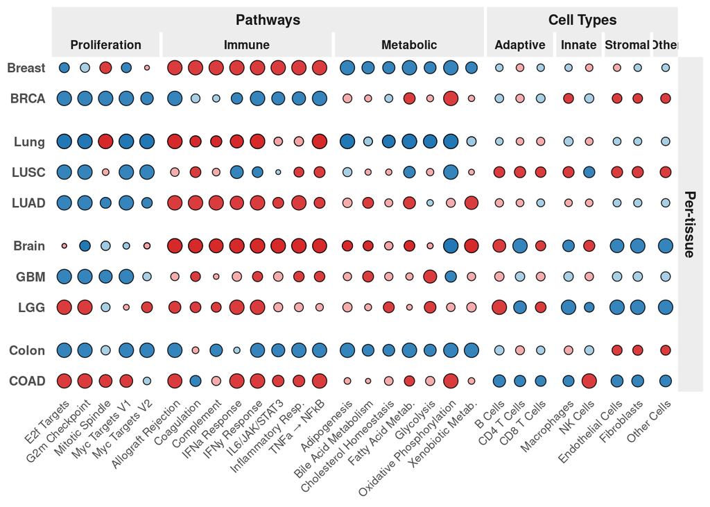

```r
# pathways (per-tissue) — signed significance, restricted to the pan-tissue panel's significant set
pw <- pathway_matched_long %>%
  dplyr::mutate(Category = assign_pathway_category(Pathway)) %>%
  dplyr::filter(Category %in% focus_categories_panelC, Pathway %in% sig_paths) %>%
  dplyr::transmute(
    Modality = "Pathways",
    Category,
    Feature = stringr::str_wrap(Pathway, 30),
    RowLab  = dplyr::if_else(grepl("^GTEx", Cohort),
                             dplyr::recode(Cohort, !!!gtex_to_display), Cohort),
    Dir  = direction,
    Sig  = ifelse(fdr < 0.05, "Sig", "NS"),
    Size = pmin(-log10(pmax(fdr, 1e-300)), 5)
  )

# cell types (per-tissue) — signed significance
ct <- celltype_matched_long %>%
  dplyr::transmute(
    Modality = "Cell Types",
    Category = cell_category_of(Cell_Group),
    Feature = stringr::str_wrap(dplyr::recode(Cell_Group, !!!cell_label_map), 18),
    RowLab  = dplyr::if_else(grepl("^GTEx", Cohort),
                             dplyr::recode(Cohort, !!!gtex_to_display), Cohort),
    Dir  = dplyr::if_else(c_effect > 0, "Up", "Down"),
    Sig  = ifelse(!is.na(c_FDR) & c_FDR < 0.05, "Sig", "NS"),
    Size = pmin(-log10(pmax(c_FDR, 1e-300)), 5)
  )

combined_BD <- dplyr::bind_rows(pw, ct) %>%
  dplyr::left_join(row_pos_tbl, by = "RowLab") %>%
  dplyr::mutate(
    Section = "Per-tissue",
    Color = dplyr::case_when(
      Dir == "Up"   & Sig == "Sig" ~ unname(agreement_fill_values["Up_Sig"]),
      Dir == "Up"   & Sig == "NS"  ~ unname(agreement_fill_values["Up_NS"]),
      Dir == "Down" & Sig == "Sig" ~ unname(agreement_fill_values["Down_Sig"]),
      Dir == "Down" & Sig == "NS"  ~ unname(agreement_fill_values["Down_NS"]),
      TRUE ~ unname(agreement_fill_values["Neutral"])
    ),
    Modality = factor(Modality, levels = c("Pathways", "Cell Types")),
    Category = factor(Category, levels = c(
      "Proliferation", "Immune", "Metabolic",
      "Adaptive", "Innate", "Stromal", "Other"
    ))
  )

feat_levels <- combined_BD %>%
  dplyr::distinct(Modality, Category, Feature) %>%
  dplyr::arrange(Modality, Category, Feature) %>%
  dplyr::pull(Feature) %>%
  unique()
combined_BD <- combined_BD %>%
  dplyr::mutate(Feature = factor(Feature, levels = feat_levels))

fig2_font <- list(base = 10, strip_mod = 10, strip_cat = 8.5,
                  strip_section = 10, axis_feat = 8, axis_row = 9)

p_combined_BD <- ggplot(combined_BD, ggplot2::aes(x = Feature, y = RowPos)) +
  ggplot2::geom_point(
    ggplot2::aes(size = Size, fill = Color),
    shape = agreement_shape, color = "black", alpha = agreement_alpha
  ) +
  ggh4x::facet_nested(
    Section ~ Modality + Category,
    scales = "free_x", space = "free_x",
    strip = ggh4x::strip_nested(
      background_x = ggh4x::elem_list_rect(fill = c("grey93", "grey93")),
      text_x = ggh4x::elem_list_text(
        size = c(fig2_font$strip_mod, fig2_font$strip_cat),
        face = c("bold", "bold")
      ),
      by_layer_x = TRUE
    )
  ) +
  ggplot2::scale_y_continuous(
    breaks = row_pos_tbl$RowPos, labels = row_pos_tbl$RowLab,
    expand = ggplot2::expansion(add = c(0.35, 0.35))
  ) +
  ggplot2::scale_fill_identity() +
  ggplot2::scale_size(range = agreement_size_range, limits = agreement_size_limits, guide = "none") +
  ggplot2::theme_minimal(base_size = fig2_font$base) +
  ggplot2::theme(
    legend.position = "none",
    axis.title.x = ggplot2::element_blank(),
    axis.title.y = ggplot2::element_blank(),
    panel.spacing.x = grid::unit(0.15, "lines"),
    strip.text.y = ggplot2::element_text(size = fig2_font$strip_section, face = "bold", angle = -90),
    strip.background = ggplot2::element_rect(fill = "grey93", color = NA),
    axis.text.x = ggplot2::element_text(size = fig2_font$axis_feat, angle = 45, hjust = 1, vjust = 1),
    axis.text.y = ggplot2::element_text(size = fig2_font$axis_row, face = "bold"),
    panel.grid.major = ggplot2::element_blank(),
    panel.grid.minor = ggplot2::element_blank()
  )

p_combined_BD
```

```r
ggsave(file.path(figures_root, "fig_pertissue_combined.pdf"),
       p_combined_BD, width = 7.5, height = 5.5, units = "in")
message("Saved: fig_pertissue_combined.pdf")
```

## Shared legend

Two standalone legends covering all panels: dot color (age-trend direction and significance category) and dot size (`-log10(FDR)`, on the same fixed scale used by every panel).

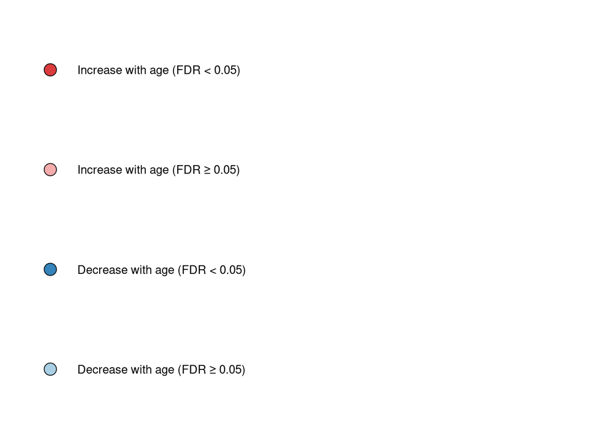

```r
# --- Color / direction-significance legend ---
legend_color_df <- tibble::tibble(
  y = 4:1,
  fill = unname(agreement_fill_values[c("Up_Sig", "Up_NS", "Down_Sig", "Down_NS")]),
  label = c(
    "Increase with age (FDR < 0.05)",
    "Increase with age (FDR \u2265 0.05)",
    "Decrease with age (FDR < 0.05)",
    "Decrease with age (FDR \u2265 0.05)"
  )
)

p_legend_color <- ggplot(legend_color_df, ggplot2::aes(x = 0, y = y)) +
  ggplot2::geom_point(ggplot2::aes(fill = fill),
                      shape = agreement_shape, size = 4.4, color = "black", alpha = agreement_alpha) +
  ggplot2::geom_text(ggplot2::aes(x = 0.12, label = label), hjust = 0, size = 3.4) +
  ggplot2::scale_fill_identity() +
  ggplot2::coord_cartesian(xlim = c(-0.1, 2.4), ylim = c(0.5, 4.5), clip = "off") +
  ggplot2::theme_void()

p_legend_color
```

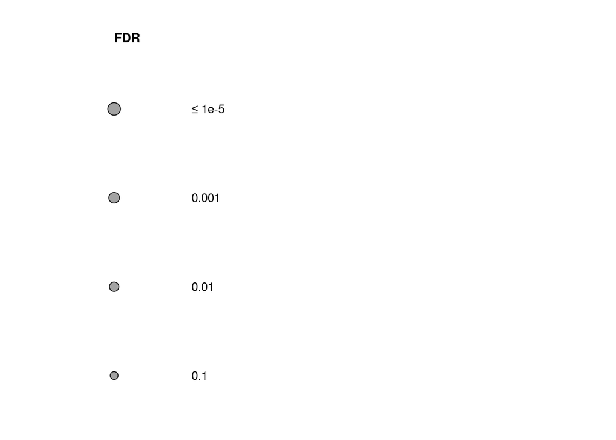

```r
ggsave(file.path(figures_root, "fig_legend_color.pdf"), p_legend_color,
       width = 3.4, height = 1.6, units = "in")
message("Saved: fig_legend_color.pdf")

# --- Size legend (dot size = -log10 FDR, capped at 5; same scale as all panels) ---
legend_size_df <- tibble::tibble(
  y = 4:1,
  size_val = c(5, 3, 2, 1),
  label = c("\u2264 1e-5", "0.001", "0.01", "0.1")
)

p_legend_size <- ggplot(legend_size_df, ggplot2::aes(x = 0, y = y)) +
  ggplot2::geom_point(ggplot2::aes(size = size_val),
                      shape = agreement_shape, fill = "grey60", color = "black", alpha = agreement_alpha) +
  ggplot2::geom_text(ggplot2::aes(x = 0.18, label = label), hjust = 0, size = 3.4) +
  ggplot2::annotate("text", x = 0, y = 4.8, label = "FDR", hjust = 0, fontface = "bold", size = 3.6) +
  ggplot2::scale_size(range = agreement_size_range, limits = agreement_size_limits, guide = "none") +
  ggplot2::coord_cartesian(xlim = c(-0.2, 1.1), ylim = c(0.5, 5.0), clip = "off") +
  ggplot2::theme_void()

p_legend_size
```

```r
ggsave(file.path(figures_root, "fig_legend_size.pdf"), p_legend_size,
       width = 1.6, height = 1.7, units = "in")
message("Saved: fig_legend_size.pdf")
```

## Supplement — full pathway agreement (pan-tissue + per-tissue, all categories)

Full pathway view: pan-tissue (GTEx, TCGA) and per-tissue blocks, all seven significant categories, nested per-tissue y-axis. Same color and size encoding as the main panels.

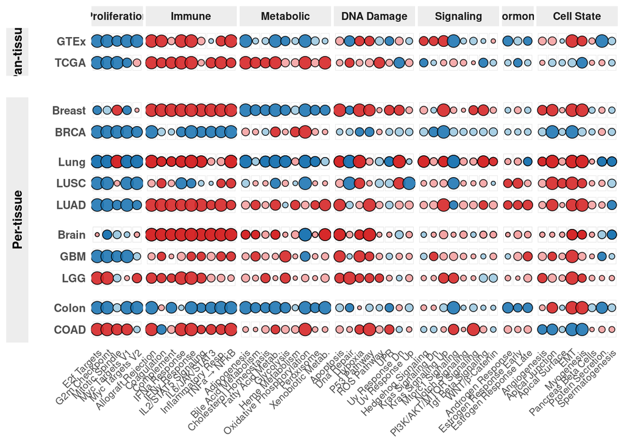

```r
gtex_tissue_label <- c(
  "GTEx-BREAST" = "Breast",
  "GTEx-LUNG"   = "Lung",
  "GTEx-BRAIN"  = "Brain",
  "GTEx-COLON"  = "Colon"
)

combined_pathway_global <- pathway_meta_long %>%
  dplyr::transmute(
    Pathway,
    Column = Cohort,
    Section = "Pan-tissue",
    TissueBlock = "Pan-tissue",
    fdr = fdr,
    direction = direction
  )

combined_pathway_matched <- pathway_matched_long %>%
  dplyr::transmute(
    Pathway,
    Column = dplyr::if_else(
      grepl("^GTEx", Cohort),
      dplyr::recode(Cohort, !!!gtex_tissue_label),
      Cohort
    ),
    Section = "Per-tissue",
    TissueBlock = dplyr::recode(
      Tissue,
      "BREAST" = "Breast",
      "LUNG"   = "Lung",
      "BRAIN"  = "Brain",
      "COLON"  = "Colon"
    ),
    fdr = fdr,
    direction = direction
  )

combined_pathway <- dplyr::bind_rows(
  combined_pathway_global,
  combined_pathway_matched
) %>%
  dplyr::mutate(
    Category = assign_pathway_category(Pathway),
    Category = factor(Category, levels = pathway_category_levels),

    Sig = ifelse(!is.na(fdr) & fdr < 0.05, "Sig", "NS"),

    Color = dplyr::case_when(
      direction == "Up"   & Sig == "Sig" ~ unname(agreement_fill_values["Up_Sig"]),
      direction == "Up"   & Sig == "NS"  ~ unname(agreement_fill_values["Up_NS"]),
      direction == "Down" & Sig == "Sig" ~ unname(agreement_fill_values["Down_Sig"]),
      direction == "Down" & Sig == "NS"  ~ unname(agreement_fill_values["Down_NS"]),
      TRUE ~ unname(agreement_fill_values["Neutral"])
    ),

    Size = pmin(-log10(pmax(fdr, 1e-300)), 5)   # signed significance, harmonized
  )

column_levels <- c(
  "GTEx", "TCGA",
  "Breast", "BRCA",
  "Lung",   "LUSC", "LUAD",
  "Brain",  "GBM",  "LGG",
  "Colon",  "COAD"
)

combined_pathway <- combined_pathway %>%
  dplyr::filter(Column %in% column_levels) %>%
  dplyr::mutate(
    Column = factor(Column, levels = rev(column_levels)),
    Section = factor(Section, levels = c("Pan-tissue", "Per-tissue")),
    TissueBlock = factor(
      TissueBlock,
      levels = c("Pan-tissue", "Breast", "Lung", "Brain", "Colon")
    )
  )

# Order pathways alphabetically within category, matching the pan-tissue panel.
pathway_order <- combined_pathway %>%
  dplyr::distinct(Category, Pathway) %>%
  dplyr::arrange(Category, Pathway) %>%
  dplyr::pull(Pathway) %>%
  unique()

combined_pathway <- combined_pathway %>%
  dplyr::mutate(
    Pathway_wrapped = stringr::str_wrap(Pathway, width = 30),
    Pathway_wrapped = factor(
      Pathway_wrapped,
      levels = stringr::str_wrap(pathway_order, width = 30)
    )
  )

p_pathway_combined <- ggplot(
  combined_pathway,
  ggplot2::aes(x = Pathway_wrapped, y = Column)
) +
  ggplot2::geom_tile(
    fill = "white",
    color = "grey90",
    height = 0.7,
    width = 0.85
  ) +
  ggplot2::geom_point(
    ggplot2::aes(size = Size, fill = Color),
    shape = agreement_shape,
    color = "black",
    alpha = agreement_alpha
  ) +
  ggh4x::facet_nested(
    Section + TissueBlock ~ Category,
    scales = "free",
    space = "free",
    switch = "y",
    strip = ggh4x::strip_nested(
      background_y = list(
        ggplot2::element_rect(fill = "grey93", colour = NA),
        ggplot2::element_blank()
      ),
      text_y = list(
        ggplot2::element_text(face = "bold", size = 10, colour = "black"),
        ggplot2::element_blank()
      ),
      by_layer_y = TRUE
    )
  ) +
  ggplot2::scale_fill_identity() +
  ggplot2::scale_size(range = agreement_size_range, limits = agreement_size_limits, guide = "none") +
  ggplot2::theme_minimal(base_size = 10) +
  ggplot2::theme(
    legend.position = "none",

    strip.placement = "outside",
    strip.switch.pad.grid = grid::unit(0.1, "lines"),

    panel.spacing.x = grid::unit(0.15, "lines"),
    panel.spacing.y = grid::unit(c(1.2, 0.2, 0.2, 0.2), "lines"),

    strip.text.x = ggplot2::element_text(size = 8.5, face = "bold"),
    strip.text.y = ggplot2::element_text(size = 10, face = "bold"),
    strip.background = ggplot2::element_rect(fill = "grey93", color = NA),

    axis.text.x = ggplot2::element_text(
      size = 8,
      angle = 45,
      hjust = 1,
      vjust = 1
    ),
    axis.text.y = ggplot2::element_text(
      size = 9,
      face = "bold"
    ),

    axis.title.x = ggplot2::element_blank(),
    axis.title.y = ggplot2::element_blank(),

    panel.grid.major = ggplot2::element_blank(),
    panel.grid.minor = ggplot2::element_blank()
  )

p_pathway_combined
```

```r
ggsave(
  file.path(figures_root, "Supplement_pathway_full_pancohort_pertissue.pdf"),
  p_pathway_combined,
  width = 10,
  height = 4.8,
  units = "in"
)

message("Saved: Supplement_pathway_full_pancohort_pertissue.pdf")
```

## Save plot source tables

```r
utils::write.csv(
  plot_pathway_meta,
  file = file.path(tables_root, "fig_pancohort_pathway_plot_table.csv"),
  row.names = FALSE
)
knitr::kable(plot_pathway_meta, caption = "Pan-tissue pathway agreement")
```

Pan-tissue pathway agreement

| Pathway | Cohort | fdr | DirLabel | Size | Category | Pathway_wrapped | Section | Sig | Color |
| --- | --- | --- | --- | --- | --- | --- | --- | --- | --- |
| Adipogenesis | GTEx | 0.0e+00 | Down | 5.0000000 | Metabolic | Adipogenesis | Pan-tissue | Sig | #1f77b4 |
| Allograft Rejection | GTEx | 9.1e-06 | Up | 5.0000000 | Immune | Allograft Rejection | Pan-tissue | Sig | #d62728 |
| Androgen Response | GTEx | 3.0e-03 | Down | 2.5228787 | Hormone | Androgen Response | Pan-tissue | Sig | #1f77b4 |
| Bile Acid Metabolism | GTEx | 5.0e-01 | Down | 0.3010300 | Metabolic | Bile Acid Metabolism | Pan-tissue | NS | #9ecae1 |
| Cholesterol Homeostasis | GTEx | 2.6e-01 | Down | 0.5850267 | Metabolic | Cholesterol Homeostasis | Pan-tissue | NS | #9ecae1 |
| Coagulation | GTEx | 4.8e-05 | Up | 4.3187588 | Immune | Coagulation | Pan-tissue | Sig | #d62728 |
| Complement | GTEx | 1.5e-01 | Up | 0.8239087 | Immune | Complement | Pan-tissue | NS | #f4a3a3 |
| Dna Repair | GTEx | 1.3e-03 | Down | 2.8860566 | DNA Damage | Dna Repair | Pan-tissue | Sig | #1f77b4 |
| E2f Targets | GTEx | 0.0e+00 | Down | 5.0000000 | Proliferation | E2f Targets | Pan-tissue | Sig | #1f77b4 |
| EMT | GTEx | 1.9e-06 | Up | 5.0000000 | Cell State | EMT | Pan-tissue | Sig | #d62728 |
| Estrogen Response Early | GTEx | 6.7e-02 | Down | 1.1739252 | Hormone | Estrogen Response Early | Pan-tissue | NS | #9ecae1 |
| Estrogen Response Late | GTEx | 3.7e-02 | Down | 1.4317983 | Hormone | Estrogen Response Late | Pan-tissue | Sig | #1f77b4 |
| Fatty Acid Metab. | GTEx | 3.0e-06 | Down | 5.0000000 | Metabolic | Fatty Acid Metab. | Pan-tissue | Sig | #1f77b4 |
| G2m Checkpoint | GTEx | 0.0e+00 | Down | 5.0000000 | Proliferation | G2m Checkpoint | Pan-tissue | Sig | #1f77b4 |
| Glycolysis | GTEx | 1.1e-02 | Down | 1.9586073 | Metabolic | Glycolysis | Pan-tissue | Sig | #1f77b4 |
| Hedgehog Signaling | GTEx | 2.1e-02 | Up | 1.6777807 | Signaling | Hedgehog Signaling | Pan-tissue | Sig | #d62728 |
| Hypoxia | GTEx | 6.8e-03 | Up | 2.1674911 | DNA Damage | Hypoxia | Pan-tissue | Sig | #d62728 |
| IL6/JAK/STAT3 | GTEx | 8.9e-01 | Down | 0.0506100 | Immune | IL6/JAK/STAT3 | Pan-tissue | NS | #9ecae1 |
| Inflammatory Resp. | GTEx | 3.1e-03 | Up | 2.5086383 | Immune | Inflammatory Resp. | Pan-tissue | Sig | #d62728 |
| IFNa Response | GTEx | 1.0e-07 | Up | 5.0000000 | Immune | IFNa Response | Pan-tissue | Sig | #d62728 |
| IFNy Response | GTEx | 0.0e+00 | Up | 5.0000000 | Immune | IFNy Response | Pan-tissue | Sig | #d62728 |
| Kras Signaling Dn | GTEx | 1.5e-02 | Up | 1.8239087 | Signaling | Kras Signaling Dn | Pan-tissue | Sig | #d62728 |
| Kras Signaling Up | GTEx | 5.1e-04 | Up | 3.2924298 | Signaling | Kras Signaling Up | Pan-tissue | Sig | #d62728 |
| Mitotic Spindle | GTEx | 1.4e-03 | Down | 2.8538720 | Proliferation | Mitotic Spindle | Pan-tissue | Sig | #1f77b4 |
| Mtorc1 Signaling | GTEx | 0.0e+00 | Down | 5.0000000 | Signaling | Mtorc1 Signaling | Pan-tissue | Sig | #1f77b4 |
| Myc Targets V1 | GTEx | 0.0e+00 | Down | 5.0000000 | Proliferation | Myc Targets V1 | Pan-tissue | Sig | #1f77b4 |
| Myc Targets V2 | GTEx | 0.0e+00 | Down | 5.0000000 | Proliferation | Myc Targets V2 | Pan-tissue | Sig | #1f77b4 |
| Myogenesis | GTEx | 3.6e-03 | Up | 2.4436975 | Cell State | Myogenesis | Pan-tissue | Sig | #d62728 |
| Oxidative Phosphorylation | GTEx | 0.0e+00 | Down | 5.0000000 | Metabolic | Oxidative Phosphorylation | Pan-tissue | Sig | #1f77b4 |
| P53 Pathway | GTEx | 6.8e-03 | Up | 2.1674911 | DNA Damage | P53 Pathway | Pan-tissue | Sig | #d62728 |
| Protein Secretion | GTEx | 0.0e+00 | Down | 5.0000000 | Cell State | Protein Secretion | Pan-tissue | Sig | #1f77b4 |
| ROS Pathway | GTEx | 5.0e-02 | Down | 1.3010300 | DNA Damage | ROS Pathway | Pan-tissue | NS | #9ecae1 |
| Tgf Beta Signaling | GTEx | 8.8e-01 | Down | 0.0555173 | Signaling | Tgf Beta Signaling | Pan-tissue | NS | #9ecae1 |
| TNFa → NFkB | GTEx | 0.0e+00 | Up | 5.0000000 | Immune | TNFa → NFkB | Pan-tissue | Sig | #d62728 |
| UPR | GTEx | 2.6e-02 | Down | 1.5850267 | DNA Damage | UPR | Pan-tissue | Sig | #1f77b4 |
| Uv Response Dn | GTEx | 8.1e-02 | Up | 1.0915150 | DNA Damage | Uv Response Dn | Pan-tissue | NS | #f4a3a3 |
| Xenobiotic Metab. | GTEx | 5.6e-01 | Down | 0.2518120 | Metabolic | Xenobiotic Metab. | Pan-tissue | NS | #9ecae1 |
| Adipogenesis | TCGA | 6.0e-07 | Up | 5.0000000 | Metabolic | Adipogenesis | Pan-tissue | Sig | #d62728 |
| Allograft Rejection | TCGA | 3.3e-05 | Up | 4.4814861 | Immune | Allograft Rejection | Pan-tissue | Sig | #d62728 |
| Androgen Response | TCGA | 3.8e-01 | Down | 0.4202164 | Hormone | Androgen Response | Pan-tissue | NS | #9ecae1 |
| Bile Acid Metabolism | TCGA | 6.0e-04 | Up | 3.2218487 | Metabolic | Bile Acid Metabolism | Pan-tissue | Sig | #d62728 |
| Cholesterol Homeostasis | TCGA | 1.9e-03 | Up | 2.7212464 | Metabolic | Cholesterol Homeostasis | Pan-tissue | Sig | #d62728 |
| Coagulation | TCGA | 2.3e-03 | Up | 2.6382722 | Immune | Coagulation | Pan-tissue | Sig | #d62728 |
| Complement | TCGA | 1.4e-04 | Up | 3.8538720 | Immune | Complement | Pan-tissue | Sig | #d62728 |
| Dna Repair | TCGA | 1.6e-02 | Up | 1.7958800 | DNA Damage | Dna Repair | Pan-tissue | Sig | #d62728 |
| E2f Targets | TCGA | 0.0e+00 | Down | 5.0000000 | Proliferation | E2f Targets | Pan-tissue | Sig | #1f77b4 |
| EMT | TCGA | 5.0e-02 | Down | 1.3010300 | Cell State | EMT | Pan-tissue | NS | #9ecae1 |
| Estrogen Response Early | TCGA | 3.6e-02 | Down | 1.4436975 | Hormone | Estrogen Response Early | Pan-tissue | Sig | #1f77b4 |
| Estrogen Response Late | TCGA | 3.8e-01 | Down | 0.4202164 | Hormone | Estrogen Response Late | Pan-tissue | NS | #9ecae1 |
| Fatty Acid Metab. | TCGA | 3.1e-05 | Up | 4.5086383 | Metabolic | Fatty Acid Metab. | Pan-tissue | Sig | #d62728 |
| G2m Checkpoint | TCGA | 0.0e+00 | Down | 5.0000000 | Proliferation | G2m Checkpoint | Pan-tissue | Sig | #1f77b4 |
| Glycolysis | TCGA | 5.3e-02 | Up | 1.2757241 | Metabolic | Glycolysis | Pan-tissue | NS | #f4a3a3 |
| Hedgehog Signaling | TCGA | 4.6e-02 | Down | 1.3372422 | Signaling | Hedgehog Signaling | Pan-tissue | Sig | #1f77b4 |
| Hypoxia | TCGA | 2.6e-01 | Up | 0.5850267 | DNA Damage | Hypoxia | Pan-tissue | NS | #f4a3a3 |
| IL6/JAK/STAT3 | TCGA | 1.3e-03 | Up | 2.8860566 | Immune | IL6/JAK/STAT3 | Pan-tissue | Sig | #d62728 |
| Inflammatory Resp. | TCGA | 3.1e-05 | Up | 4.5086383 | Immune | Inflammatory Resp. | Pan-tissue | Sig | #d62728 |
| IFNa Response | TCGA | 0.0e+00 | Up | 5.0000000 | Immune | IFNa Response | Pan-tissue | Sig | #d62728 |
| IFNy Response | TCGA | 0.0e+00 | Up | 5.0000000 | Immune | IFNy Response | Pan-tissue | Sig | #d62728 |
| Kras Signaling Dn | TCGA | 6.2e-01 | Down | 0.2076083 | Signaling | Kras Signaling Dn | Pan-tissue | NS | #9ecae1 |
| Kras Signaling Up | TCGA | 4.3e-01 | Up | 0.3665315 | Signaling | Kras Signaling Up | Pan-tissue | NS | #f4a3a3 |
| Mitotic Spindle | TCGA | 0.0e+00 | Down | 5.0000000 | Proliferation | Mitotic Spindle | Pan-tissue | Sig | #1f77b4 |
| Mtorc1 Signaling | TCGA | 9.8e-02 | Up | 1.0087739 | Signaling | Mtorc1 Signaling | Pan-tissue | NS | #f4a3a3 |
| Myc Targets V1 | TCGA | 1.1e-02 | Down | 1.9586073 | Proliferation | Myc Targets V1 | Pan-tissue | Sig | #1f77b4 |
| Myc Targets V2 | TCGA | 1.2e-01 | Up | 0.9208188 | Proliferation | Myc Targets V2 | Pan-tissue | NS | #f4a3a3 |
| Myogenesis | TCGA | 9.1e-04 | Down | 3.0409586 | Cell State | Myogenesis | Pan-tissue | Sig | #1f77b4 |
| Oxidative Phosphorylation | TCGA | 0.0e+00 | Up | 5.0000000 | Metabolic | Oxidative Phosphorylation | Pan-tissue | Sig | #d62728 |
| P53 Pathway | TCGA | 6.5e-02 | Up | 1.1870866 | DNA Damage | P53 Pathway | Pan-tissue | NS | #f4a3a3 |
| Protein Secretion | TCGA | 4.8e-01 | Up | 0.3187588 | Cell State | Protein Secretion | Pan-tissue | NS | #f4a3a3 |
| ROS Pathway | TCGA | 6.4e-04 | Up | 3.1938200 | DNA Damage | ROS Pathway | Pan-tissue | Sig | #d62728 |
| Tgf Beta Signaling | TCGA | 1.5e-02 | Down | 1.8239087 | Signaling | Tgf Beta Signaling | Pan-tissue | Sig | #1f77b4 |
| TNFa → NFkB | TCGA | 6.0e-03 | Up | 2.2218487 | Immune | TNFa → NFkB | Pan-tissue | Sig | #d62728 |
| UPR | TCGA | 2.3e-01 | Up | 0.6382722 | DNA Damage | UPR | Pan-tissue | NS | #f4a3a3 |
| Uv Response Dn | TCGA | 8.4e-04 | Down | 3.0757207 | DNA Damage | Uv Response Dn | Pan-tissue | Sig | #1f77b4 |
| Xenobiotic Metab. | TCGA | 6.0e-07 | Up | 5.0000000 | Metabolic | Xenobiotic Metab. | Pan-tissue | Sig | #d62728 |

```r
utils::write.csv(
  plot_celltype_meta,
  file = file.path(tables_root, "fig_pancohort_celltype_plot_table.csv"),
  row.names = FALSE
)
knitr::kable(plot_celltype_meta, caption = "Pan-tissue cell-type agreement")
```

Pan-tissue cell-type agreement

| Cell_Group | k | est | se_meta | ci_lb | ci_ub | pval | tau2 | Cohort | fdr | Section | Sig | Dir | Color | Score | Size | Category | Cell_Group_pretty | Cell_wrapped |
| --- | --- | --- | --- | --- | --- | --- | --- | --- | --- | --- | --- | --- | --- | --- | --- | --- | --- | --- |
| Bcells | 27 | 0.0256608 | 0.0425085 | -0.0576543 | 0.1089759 | 0.5460678 | 0.0293943 | GTEx | 0.5460678 | Pan-tissue | NS | Pos | #f4a3a3 | 0.2627534 | 0.2627534 | Adaptive | B Cells | B Cells |
| CAFs | 27 | -0.0368719 | 0.0135524 | -0.0634341 | -0.0103097 | 0.0065145 | 0.0024676 | GTEx | 0.0115600 | Pan-tissue | Sig | Neg | #1f77b4 | -1.9370409 | 1.9370409 | Stromal | Fibroblasts | Fibroblasts |
| CD4_Tcells | 27 | -0.0198140 | 0.0128976 | -0.0450929 | 0.0054649 | 0.1244763 | 0.0018537 | GTEx | 0.1422586 | Pan-tissue | NS | Neg | #9ecae1 | -0.8469215 | 0.8469215 | Adaptive | CD4 T Cells | CD4 T Cells |
| CD8_Tcells | 27 | 0.0430826 | 0.0160380 | 0.0116488 | 0.0745164 | 0.0072250 | 0.0000001 | GTEx | 0.0115600 | Pan-tissue | Sig | Pos | #d62728 | 1.9370409 | 1.9370409 | Adaptive | CD8 T Cells | CD8 T Cells |
| Endothelial | 27 | -0.0402907 | 0.0133676 | -0.0664908 | -0.0140907 | 0.0025778 | 0.0021860 | GTEx | 0.0103112 | Pan-tissue | Sig | Neg | #1f77b4 | -1.9866890 | 1.9866890 | Stromal | Endothelial Cells | Endothelial Cells |
| Macrophages | 27 | -0.0478169 | 0.0100979 | -0.0676084 | -0.0280254 | 0.0000022 | 0.0003347 | GTEx | 0.0000175 | Pan-tissue | Sig | Neg | #1f77b4 | -4.7570769 | 4.7570769 | Innate | Macrophages | Macrophages |
| NKcells | 27 | 0.0752768 | 0.0483094 | -0.0194079 | 0.1699615 | 0.1191805 | 0.0170368 | GTEx | 0.1422586 | Pan-tissue | NS | Pos | #f4a3a3 | 0.8469215 | 0.8469215 | Innate | NK Cells | NK Cells |
| otherCells | 27 | -0.0386216 | 0.0135210 | -0.0651223 | -0.0121209 | 0.0042846 | 0.0026582 | GTEx | 0.0114256 | Pan-tissue | Sig | Neg | #1f77b4 | -1.9421194 | 1.9421194 | Other | Other Cells | Other Cells |
| Bcells | 31 | 0.0444401 | 0.0367329 | -0.0275550 | 0.1164352 | 0.2263482 | 0.0256201 | TCGA | 0.2586837 | Pan-tissue | NS | Pos | #f4a3a3 | 0.5872310 | 0.5872310 | Adaptive | B Cells | B Cells |
| CAFs | 31 | -0.0359052 | 0.0118926 | -0.0592143 | -0.0125962 | 0.0025351 | 0.0021354 | TCGA | 0.0101403 | Pan-tissue | Sig | Neg | #1f77b4 | -1.9939496 | 1.9939496 | Stromal | Fibroblasts | Fibroblasts |
| CD4_Tcells | 31 | -0.0318998 | 0.0100652 | -0.0516272 | -0.0121724 | 0.0015279 | 0.0007209 | TCGA | 0.0101403 | Pan-tissue | Sig | Neg | #1f77b4 | -1.9939496 | 1.9939496 | Adaptive | CD4 T Cells | CD4 T Cells |
| CD8_Tcells | 31 | -0.0149058 | 0.0162799 | -0.0468138 | 0.0170021 | 0.3598770 | 0.0011558 | TCGA | 0.3598770 | Pan-tissue | NS | Neg | #9ecae1 | -0.4438459 | 0.4438459 | Adaptive | CD8 T Cells | CD8 T Cells |
| Endothelial | 31 | -0.0332792 | 0.0128610 | -0.0584863 | -0.0080721 | 0.0096645 | 0.0028267 | TCGA | 0.0193290 | Pan-tissue | Sig | Neg | #1f77b4 | -1.7137900 | 1.7137900 | Stromal | Endothelial Cells | Endothelial Cells |
| Macrophages | 31 | -0.0196439 | 0.0131892 | -0.0454943 | 0.0062065 | 0.1363855 | 0.0030367 | TCGA | 0.1858290 | Pan-tissue | NS | Neg | #9ecae1 | -0.7308865 | 0.7308865 | Innate | Macrophages | Macrophages |
| NKcells | 31 | 0.0818191 | 0.0553530 | -0.0266707 | 0.1903089 | 0.1393717 | 0.0380267 | TCGA | 0.1858290 | Pan-tissue | NS | Pos | #f4a3a3 | 0.7308865 | 0.7308865 | Innate | NK Cells | NK Cells |
| otherCells | 31 | -0.0327889 | 0.0125214 | -0.0573304 | -0.0082473 | 0.0088286 | 0.0028778 | TCGA | 0.0193290 | Pan-tissue | Sig | Neg | #1f77b4 | -1.7137900 | 1.7137900 | Other | Other Cells | Other Cells |

```r
utils::write.csv(
  combined_BD,
  file = file.path(tables_root, "fig_pertissue_combined_plot_table.csv"),
  row.names = FALSE
)
knitr::kable(combined_BD, caption = "Per-tissue combined pathways and cell types")
```

Per-tissue combined pathways and cell types

| Modality | Category | Feature | RowLab | Dir | Sig | Size | RowPos | Section | Color |
| --- | --- | --- | --- | --- | --- | --- | --- | --- | --- |
| Pathways | Metabolic | Adipogenesis | Breast | Down | Sig | 5.0000000 | 10.0 | Per-tissue | #1f77b4 |
| Pathways | Immune | Allograft Rejection | Breast | Up | Sig | 5.0000000 | 10.0 | Per-tissue | #d62728 |
| Pathways | Metabolic | Bile Acid Metabolism | Breast | Down | Sig | 3.1249387 | 10.0 | Per-tissue | #1f77b4 |
| Pathways | Metabolic | Cholesterol Homeostasis | Breast | Down | Sig | 3.0087739 | 10.0 | Per-tissue | #1f77b4 |
| Pathways | Immune | Coagulation | Breast | Up | Sig | 5.0000000 | 10.0 | Per-tissue | #d62728 |
| Pathways | Immune | Complement | Breast | Up | Sig | 5.0000000 | 10.0 | Per-tissue | #d62728 |
| Pathways | Proliferation | E2f Targets | Breast | Down | Sig | 1.5086383 | 10.0 | Per-tissue | #1f77b4 |
| Pathways | Metabolic | Fatty Acid Metab. | Breast | Down | Sig | 5.0000000 | 10.0 | Per-tissue | #1f77b4 |
| Pathways | Proliferation | G2m Checkpoint | Breast | Down | NS | 1.1611509 | 10.0 | Per-tissue | #9ecae1 |
| Pathways | Metabolic | Glycolysis | Breast | Down | Sig | 2.7447275 | 10.0 | Per-tissue | #1f77b4 |
| Pathways | Immune | IL6/JAK/STAT3 | Breast | Up | Sig | 5.0000000 | 10.0 | Per-tissue | #d62728 |
| Pathways | Immune | Inflammatory Resp. | Breast | Up | Sig | 5.0000000 | 10.0 | Per-tissue | #d62728 |
| Pathways | Immune | IFNa Response | Breast | Up | Sig | 5.0000000 | 10.0 | Per-tissue | #d62728 |
| Pathways | Immune | IFNy Response | Breast | Up | Sig | 5.0000000 | 10.0 | Per-tissue | #d62728 |
| Pathways | Proliferation | Mitotic Spindle | Breast | Up | Sig | 2.5850267 | 10.0 | Per-tissue | #d62728 |
| Pathways | Proliferation | Myc Targets V1 | Breast | Down | Sig | 1.5086383 | 10.0 | Per-tissue | #1f77b4 |
| Pathways | Proliferation | Myc Targets V2 | Breast | Up | NS | 0.0043648 | 10.0 | Per-tissue | #f4a3a3 |
| Pathways | Metabolic | Oxidative Phosphorylation | Breast | Down | Sig | 5.0000000 | 10.0 | Per-tissue | #1f77b4 |
| Pathways | Immune | TNFa → NFkB | Breast | Up | Sig | 5.0000000 | 10.0 | Per-tissue | #d62728 |
| Pathways | Metabolic | Xenobiotic Metab. | Breast | Down | Sig | 2.5528420 | 10.0 | Per-tissue | #1f77b4 |
| Pathways | Metabolic | Adipogenesis | BRCA | Up | NS | 0.9586073 | 9.0 | Per-tissue | #f4a3a3 |
| Pathways | Immune | Allograft Rejection | BRCA | Down | Sig | 5.0000000 | 9.0 | Per-tissue | #1f77b4 |
| Pathways | Metabolic | Bile Acid Metabolism | BRCA | Up | NS | 0.3187588 | 9.0 | Per-tissue | #f4a3a3 |
| Pathways | Metabolic | Cholesterol Homeostasis | BRCA | Down | NS | 0.6197888 | 9.0 | Per-tissue | #9ecae1 |
| Pathways | Immune | Coagulation | BRCA | Down | NS | 1.0000000 | 9.0 | Per-tissue | #9ecae1 |
| Pathways | Immune | Complement | BRCA | Down | NS | 0.3767507 | 9.0 | Per-tissue | #9ecae1 |
| Pathways | Proliferation | E2f Targets | BRCA | Down | Sig | 5.0000000 | 9.0 | Per-tissue | #1f77b4 |
| Pathways | Metabolic | Fatty Acid Metab. | BRCA | Up | Sig | 2.3767507 | 9.0 | Per-tissue | #d62728 |
| Pathways | Proliferation | G2m Checkpoint | BRCA | Down | Sig | 5.0000000 | 9.0 | Per-tissue | #1f77b4 |
| Pathways | Metabolic | Glycolysis | BRCA | Up | NS | 0.2757241 | 9.0 | Per-tissue | #f4a3a3 |

[output cut: 290 more lines]

```r
utils::write.csv(
  combined_pathway,
  file = file.path(tables_root, "Supplement_pathway_full_plot_table.csv"),
  row.names = FALSE
)
knitr::kable(combined_pathway, caption = "Full pathway agreement supplement")
```

Full pathway agreement supplement

| Pathway | Column | Section | TissueBlock | fdr | direction | Category | Sig | Color | Size | Pathway_wrapped |
| --- | --- | --- | --- | --- | --- | --- | --- | --- | --- | --- |
| Adipogenesis | GTEx | Pan-tissue | Pan-tissue | 0.0e+00 | Down | Metabolic | Sig | #1f77b4 | 5.0000000 | Adipogenesis |
| Allograft Rejection | GTEx | Pan-tissue | Pan-tissue | 9.1e-06 | Up | Immune | Sig | #d62728 | 5.0000000 | Allograft Rejection |
| Androgen Response | GTEx | Pan-tissue | Pan-tissue | 3.0e-03 | Down | Hormone | Sig | #1f77b4 | 2.5228787 | Androgen Response |
| Angiogenesis | GTEx | Pan-tissue | Pan-tissue | 8.5e-02 | Up | Cell State | NS | #f4a3a3 | 1.0705811 | Angiogenesis |
| Apical Junction | GTEx | Pan-tissue | Pan-tissue | 5.4e-02 | Up | Cell State | NS | #f4a3a3 | 1.2676062 | Apical Junction |
| Apical Surface | GTEx | Pan-tissue | Pan-tissue | 9.5e-01 | Down | Cell State | NS | #9ecae1 | 0.0222764 | Apical Surface |
| Apoptosis | GTEx | Pan-tissue | Pan-tissue | 6.3e-02 | Up | DNA Damage | NS | #f4a3a3 | 1.2006595 | Apoptosis |
| Bile Acid Metabolism | GTEx | Pan-tissue | Pan-tissue | 5.0e-01 | Down | Metabolic | NS | #9ecae1 | 0.3010300 | Bile Acid Metabolism |
| Cholesterol Homeostasis | GTEx | Pan-tissue | Pan-tissue | 2.6e-01 | Down | Metabolic | NS | #9ecae1 | 0.5850267 | Cholesterol Homeostasis |
| Coagulation | GTEx | Pan-tissue | Pan-tissue | 4.8e-05 | Up | Immune | Sig | #d62728 | 4.3187588 | Coagulation |
| Complement | GTEx | Pan-tissue | Pan-tissue | 1.5e-01 | Up | Immune | NS | #f4a3a3 | 0.8239087 | Complement |
| Dna Repair | GTEx | Pan-tissue | Pan-tissue | 1.3e-03 | Down | DNA Damage | Sig | #1f77b4 | 2.8860566 | Dna Repair |
| E2f Targets | GTEx | Pan-tissue | Pan-tissue | 0.0e+00 | Down | Proliferation | Sig | #1f77b4 | 5.0000000 | E2f Targets |
| EMT | GTEx | Pan-tissue | Pan-tissue | 1.9e-06 | Up | Cell State | Sig | #d62728 | 5.0000000 | EMT |
| Estrogen Response Early | GTEx | Pan-tissue | Pan-tissue | 6.7e-02 | Down | Hormone | NS | #9ecae1 | 1.1739252 | Estrogen Response Early |
| Estrogen Response Late | GTEx | Pan-tissue | Pan-tissue | 3.7e-02 | Down | Hormone | Sig | #1f77b4 | 1.4317983 | Estrogen Response Late |
| Fatty Acid Metab. | GTEx | Pan-tissue | Pan-tissue | 3.0e-06 | Down | Metabolic | Sig | #1f77b4 | 5.0000000 | Fatty Acid Metab. |
| G2m Checkpoint | GTEx | Pan-tissue | Pan-tissue | 0.0e+00 | Down | Proliferation | Sig | #1f77b4 | 5.0000000 | G2m Checkpoint |
| Glycolysis | GTEx | Pan-tissue | Pan-tissue | 1.1e-02 | Down | Metabolic | Sig | #1f77b4 | 1.9586073 | Glycolysis |
| Hedgehog Signaling | GTEx | Pan-tissue | Pan-tissue | 2.1e-02 | Up | Signaling | Sig | #d62728 | 1.6777807 | Hedgehog Signaling |
| Heme Metabolism | GTEx | Pan-tissue | Pan-tissue | 2.6e-01 | Down | Metabolic | NS | #9ecae1 | 0.5850267 | Heme Metabolism |
| Hypoxia | GTEx | Pan-tissue | Pan-tissue | 6.8e-03 | Up | DNA Damage | Sig | #d62728 | 2.1674911 | Hypoxia |
| IL2/STAT5 Signaling | GTEx | Pan-tissue | Pan-tissue | 1.1e-01 | Up | Immune | NS | #f4a3a3 | 0.9586073 | IL2/STAT5 Signaling |
| IL6/JAK/STAT3 | GTEx | Pan-tissue | Pan-tissue | 8.9e-01 | Down | Immune | NS | #9ecae1 | 0.0506100 | IL6/JAK/STAT3 |
| Inflammatory Resp. | GTEx | Pan-tissue | Pan-tissue | 3.1e-03 | Up | Immune | Sig | #d62728 | 2.5086383 | Inflammatory Resp. |
| IFNa Response | GTEx | Pan-tissue | Pan-tissue | 1.0e-07 | Up | Immune | Sig | #d62728 | 5.0000000 | IFNa Response |
| IFNy Response | GTEx | Pan-tissue | Pan-tissue | 0.0e+00 | Up | Immune | Sig | #d62728 | 5.0000000 | IFNy Response |
| Kras Signaling Dn | GTEx | Pan-tissue | Pan-tissue | 1.5e-02 | Up | Signaling | Sig | #d62728 | 1.8239087 | Kras Signaling Dn |
| Kras Signaling Up | GTEx | Pan-tissue | Pan-tissue | 5.1e-04 | Up | Signaling | Sig | #d62728 | 3.2924298 | Kras Signaling Up |
| Mitotic Spindle | GTEx | Pan-tissue | Pan-tissue | 1.4e-03 | Down | Proliferation | Sig | #1f77b4 | 2.8538720 | Mitotic Spindle |

[output cut: 670 more lines]